# What Affects Lenders' Contribution to Peer-to-peer Lending? -- An Exploration on the Antecedants.

## by Jinyan Xiang

## Investigation Overview

In this investigation, I focused on exploring the antecedants of lenders' average lending amount for each listing, which is a proxy of lenders' contribution to the peer-to-peer lending, and more broadly, their engagement in the sharing economy.

## Dataset Overview

To explore the antecedants of lenders' average lending amount, I retrieved loan listing data from Prosper -- a leading p2p lending platform in the US.

After excluding duplicated listings and extreme outliers, and listings that are not fully funded, the dataset for further analysis contains 112,196 unique fully-funded Prosper loan listings created and funded between November 2005 and March 2014 in 51 US states and Washington DC.

## The Outcome Variable

The focal outcome variable in this investigation is Average Lending Amount, which is calculated as Loan Original Amount divided by the number of Investors. It is a proxy of lender's contribution to the p2p lending and more broadly, engagement in the sharing economy, which is a crucial metric that both sharing economy platforms and policymakers are interested in.

## Focal Predictors

I explored these antecedants of lenders' average lending amount from three aspects -- borrowers', lenders' and loans', specifically,

1. borrower's Prosper Score -- an integrated metric of the borrower's credibility (range from 1 to 11, incremental by 1, the higher ,the more credible and less risky, the greater average lending amount)
2. borrower's Stated Monthly Income-- an indicator of the borrowe's payment ability (the higher, the stronger payment ability and less riksy, the greater average lending amount)
3. lender's Yield -- an indicator of expected ROI in the lending (the higher, the better ROI, the greater average lending amount)
4. loan's Term -- a determinant of ROI rate (could be complicated based on the formula)

## Distribution of the Outcome Variable (Average Lending)

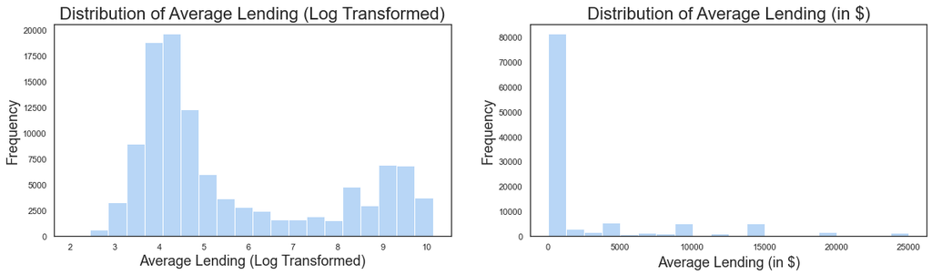

## Distribution of Focal Predictors

The majority of borrowers have a monthly income ranging from 2,000 dollars to 5,000 dollars (48%) and a prosper score ranging from 4 to 8 (68%).  
The majority of loans have a lender's yield ranging from 0.08 to 0.2 (55%) and a term of 36 months (77%).

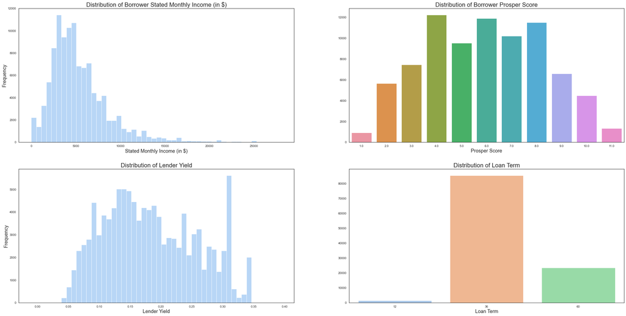

## Correlation Plots: Average Lending vs. Stated Monthly Income, Prosper Score, Lender Yield

Stated monthly income, prosper score and lender yield have a positive, negative and negligible correlation with average lending amount.

##### Note:

###### 1. Average lending amount is log transformed to address skewness.

###### 2. Prosper Score is treated as countinous (vs. essentially discrete) for exploration purpose.

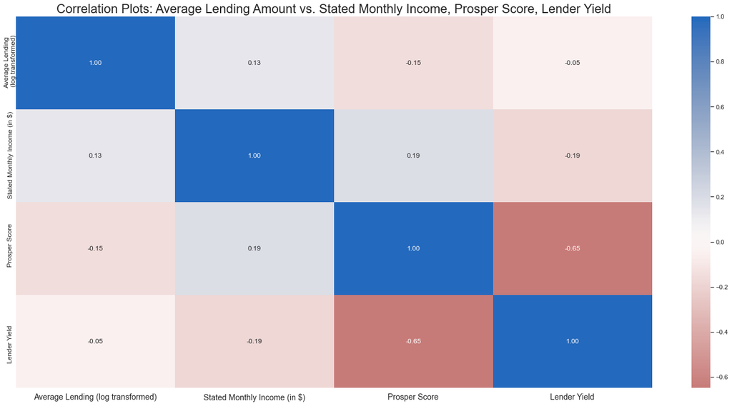

## Scatter Plots: Average Lending vs. Stated Monthly Income, Prosper Score, Lender Yield

The positive, negative and negligible relationships between tated monthly income, prosper score and lender yield and average lending amount are further confirmed.

##### Note:

###### 1. Average lending amount is log transformed to address skewness.

###### 2. Prosper Score here is treated as countinous (vs. essentially discrete) for exploration purpose.

###### 3. A random sample of 1,000 listings is used for a neater visualization.

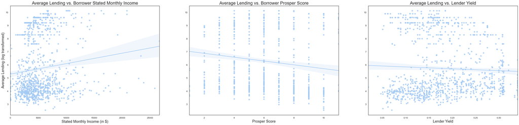

## Bar Plots: Average Lending vs. Stated Monthly Income, Prosper Score, Lender Yield

- Treating *Prosper Score* as a discrete variable reveals more nuanced relationship between it and average lending amount: there is a positive relationship when prosper score is relative low (1-4) and almost no relationship when it is in the middle (5-7) and regain a general positive relationship when it is high (8-11).
- The longer loan's term, the more average lending amount for the listing.

##### Note:

###### 1. Average lending amount is log transformed to address skewness.

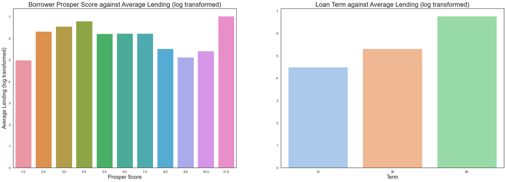

## Interaction between Prosper Score and Stated Monthly Income on Average Lending

##### Note:

###### 1. Prosper score is categoried into three levels based on its original value: low (1-4), med (5-7), high (8-11).

###### 2. Listings without prosper score is excluded for a neater virsualization.

###### 3. Average lending amount is log transformed to address skewness.

###### 4. A random sample of 1000 listings is used for a neater visualization.

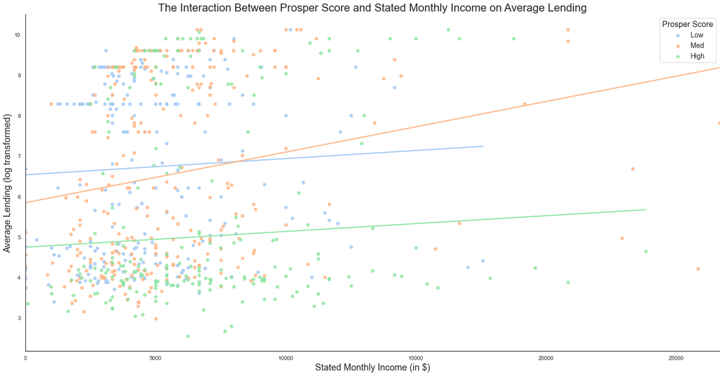

## Interaction between Prosper Score and Lender Yield on Average Lending

There is a significant interaction between borrower's prosper score and lender yield. Specifically, lender yield has a negative effect on average lending amount when borrowers have low and med prosper scores, and such negative effects diminish when borrowers have high prosper score.

##### Note:

###### 1. Prosper score is categoried into three levels based on its original value: low (1-4), med (5-7), high (8-11).

###### 2. Listings without prosper score is excluded for a neater virsualization.

###### 3. Average lending amount is log transformed to address skewness.

###### 4. A random sample of 1000 listings is used for a neater visualization.

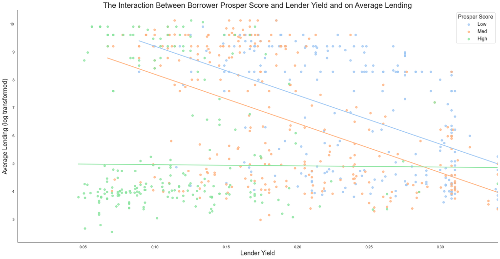

There is a significant interaction between loan term and lender yield. Specifically, lender yield has a negative effect on average lending amount when the term is 60 months, and such negative effect diminish when the loan term is 12 months or 36 months.

##### Note:

###### 1. Average lending amount is log transformed to address skewness.

###### 2. A random sample of 1000 listings is used for a neater visualization.

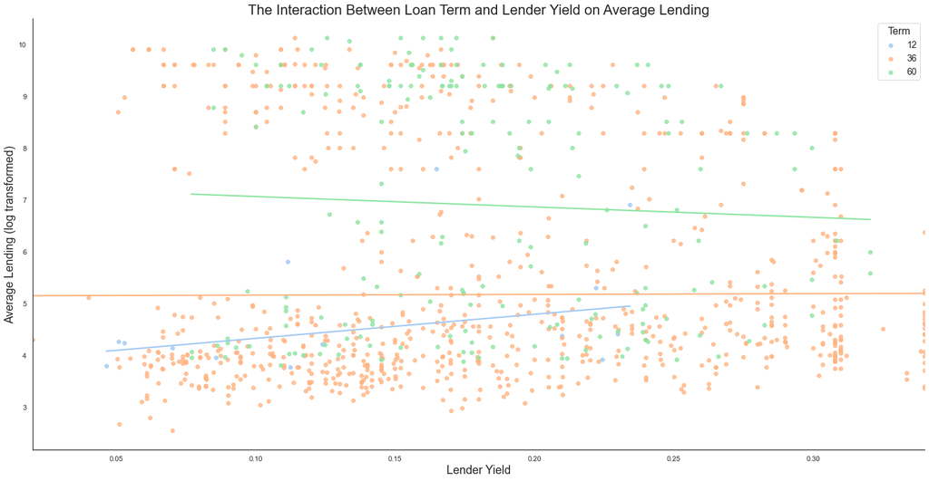

## THANK YOU :)

### contact me @ yan471025@gmail.com